# Assignment 4

Veronica Rosado

11/28/2021

# Introduction

Emil City is looking to more efficiently target home owners who are eligible for a home repair tax credit program. Although the city’s Department of Housing and Community Development reaches out to eligible homeowners, only 11% avail of the credit. This project aims to develop a model to identify eligible homeowners who are more likely to take the credit. The findings will help inform the HCD so they could focus their marketing efforts and maximize outcomes.

# Exploratory Analysis

Based on HCD’s records from previous campaigns, only 451 (11%) homeowners took the credit. These records also include various information on homeowners which we will use to develop a model predicting the homeowner’s likelihood of accepting the credit. The variables are divided into three groups - continuous outcomes, binary variables (Yes / No), and multi-category features.

In Figure 1, some variables have significantly different yes and no outcomes. Individuals are less likely to use the tax credit program if they have been contacted more times `campaign`, more days have passed since they were last contacted from a previous program `pdays`, and if `inflation` is higher. If individuals have been contacted more times before this campaign, they are more likely to use the tax program`previous`.

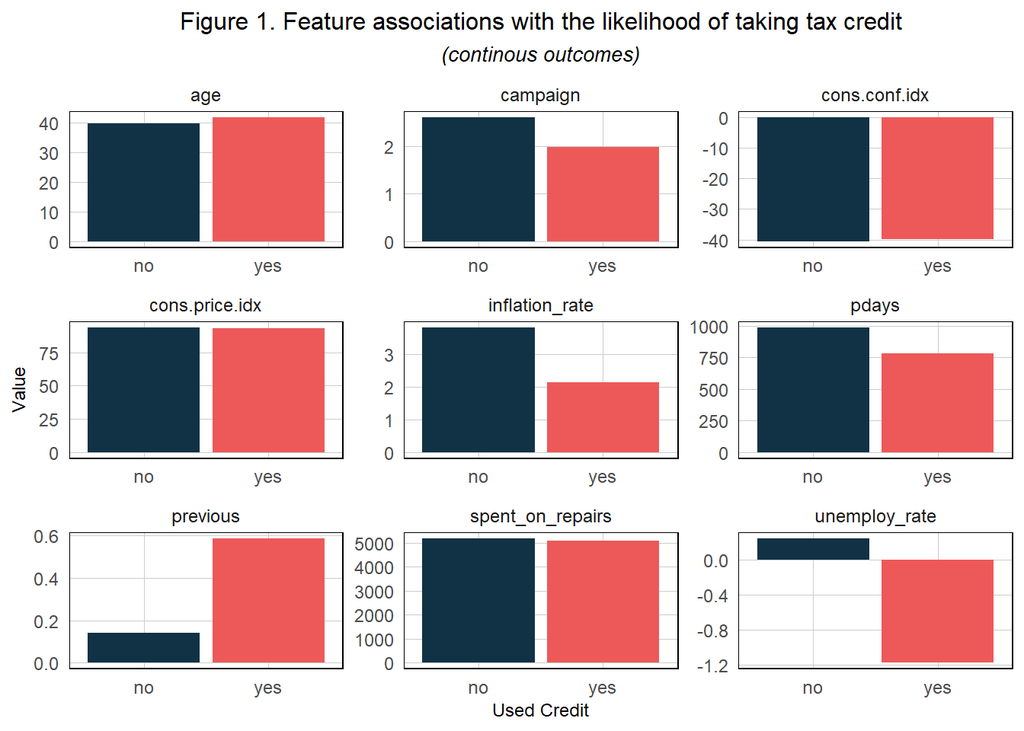

```r
#Continuous- Numeric
housing %>%
  dplyr::select(y,age, unemploy_rate,inflation_rate, spent_on_repairs, campaign, previous, cons.price.idx,cons.conf.idx, pdays) %>%
  gather(Variable, value, -y) %>%
    ggplot(aes(y, value, fill=y)) +
      geom_bar(position = "dodge", stat = "summary", fun.y = "mean") +
      facet_wrap(~Variable, scales = "free") +
      scale_fill_manual(values = palette2) +
      labs(x="Used Credit", y="Value",
           title = "Figure 1. Feature associations with the likelihood of taking tax credit",
           subtitle = "(continous outcomes)") +
      theme(legend.position = "none")+
  plotTheme()
```

We also created a distribution plot for these continuous variables. Figure 2 shows that there are variations in credit uptake within certain features. For example, fewer homeowners under 50 years old are taking the credit. At lower inflation rates, more homeowners take the credit, but at higher inflation rates, less homeowners do so.

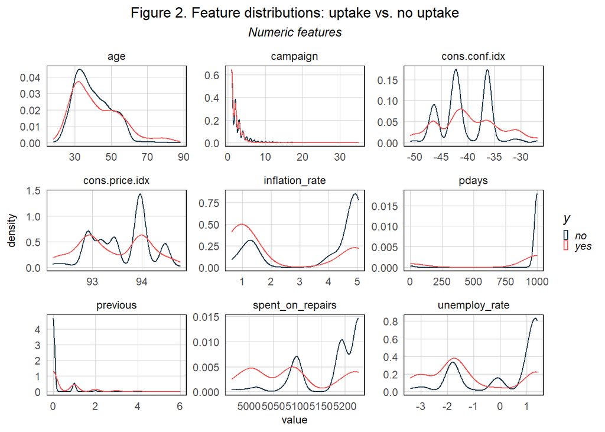

```r
housing %>%
    dplyr::select(y, age, campaign, previous, unemploy_rate, cons.price.idx, cons.conf.idx, inflation_rate, pdays, previous, spent_on_repairs, unemploy_rate) %>%
    gather(Variable, value, -y) %>%
    ggplot() +
    geom_density(aes(value, color=y), fill = "transparent") +
    facet_wrap(~Variable, scales = "free") +
    scale_color_manual(values = palette2) +
    labs(title = "Figure 2. Feature distributions: uptake vs. no uptake",
         subtitle = "Numeric features") +
  plotTheme()
```

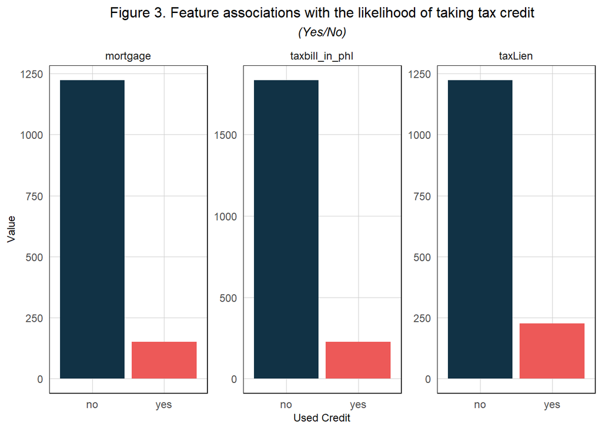

```r
# Yes/No
housing %>%
  dplyr::select(y,mortgage, taxbill_in_phl, taxLien) %>%
  gather(Variable, value, -y) %>%
  count(Variable, value, y) %>%
    ggplot(aes(y, n, fill=y)) +
      geom_bar(position = "dodge", stat = "summary", fun.y = "mean") +
      facet_wrap(~Variable, scales = "free") +
      scale_fill_manual(values = palette2) +
      labs(x="Used Credit", y="Value",
           title = "Figure 3. Feature associations with the likelihood of taking tax credit",
           subtitle = "(Yes/No)") +
      theme(legend.position = "none")+
  plotTheme()
```

For multiple category variables, the likelihood of accepting credit depends on the `education` levels, `marital` status, certain `months` of the year, the type of `job`, mode of `contact`, and `poutcome` of previous marketing campaigns.

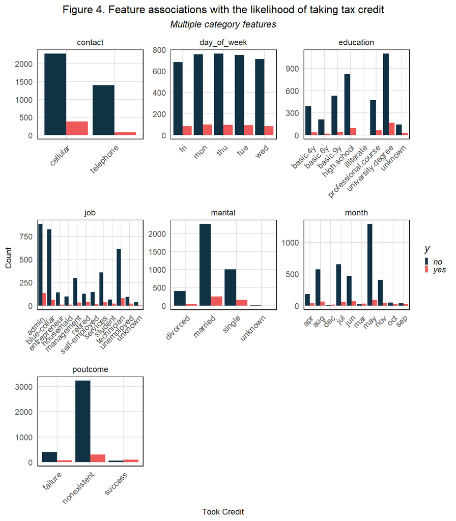

```r
#Categorical
housing %>%
  dplyr::select(y, job, marital, education, contact, month, day_of_week, poutcome) %>%
  gather(Variable, value, -y) %>%
  count(Variable, value, y) %>%
  ggplot(aes(value, n, fill = y)) +
    geom_bar(position = "dodge", stat="identity") +
    facet_wrap(~Variable, scales="free") +
    scale_fill_manual(values = palette2) +
    labs(x="Took Credit", y="Count",
         title = "Figure 4. Feature associations with the likelihood of taking tax credit",
         subtitle = "Multiple category features") +
    theme(axis.text.x = element_text(angle=45, hjust=1))+
  plotTheme()
```

# Logistic Regression

## Kitchen sink model

In the kitchen sink model, we included most of the features in HCD’s records, except for those that did not have substantially different yes and no outcomes. We also split our data into a 65-35 to test the model. The regression results show that only some of the variables are significant.

```r
set.seed(3456)
trainIndex <- createDataPartition(y = paste(housing$taxLien), p = .65, list = FALSE, times = 1)

housingTrain <- housing[ trainIndex,]
housingTest  <- housing[-trainIndex,]

kitchensink <- glm(y_numeric ~ .,
                   data=housingTrain %>%
                   dplyr::select(-cons.price.idx, -cons.conf.idx, -y, -spent_on_repairs, -previous, -education), family="binomial" (link="logit"))


stargazer(kitchensink, type = "text",
          title="Regression Results - Kitchen Sink Model")
```

```
##
## Regression Results - Kitchen Sink Model
## ===============================================
##                         Dependent variable:
##                     ---------------------------
##                              y_numeric
## -----------------------------------------------
## X                             -0.0001
##                              (0.0001)
##
## age                           0.018**
##                               (0.008)
##
## jobblue-collar                -0.444*
##                               (0.234)
##
## jobentrepreneur               -0.321
##                               (0.434)
##
## jobhousemaid                  -0.702
##                               (0.517)
##
## jobmanagement                -0.646**
##                               (0.324)
##
## jobretired                    -0.116
##                               (0.358)
##
## jobself-employed              -0.410
##                               (0.408)
##
## jobservices                   -0.218
##                               (0.274)
##
## jobstudent                    -0.086
##                               (0.411)
##
## jobtechnician                  0.174
##                               (0.204)
##
```

[output cut: 84 more lines]

```
## unemploy_rate                  0.178
##                               (0.147)
##
## inflation_rate               -0.618***
##                               (0.146)
##
## Constant                      -0.976
##                               (0.952)
##
## -----------------------------------------------
## Observations                   2,678
## Log Likelihood               -736.221
## Akaike Inf. Crit.            1,556.441
## ===============================================
## Note:               *p<0.1; **p<0.05; ***p<0.01
```

```r
#McFadden is 0.23
```

# Distribution of predicted probabilities

The plot below shows the distribution of the predicted probabilities for yes and no outcomes. We see that the ‘hump’ of predicted probabilities of not taking the credit clusters around 0. For those taking credit, the ’hump’should be closer to 1. This indicates that our kitchen sink model has better predictive power for negative results, but not for positive results.

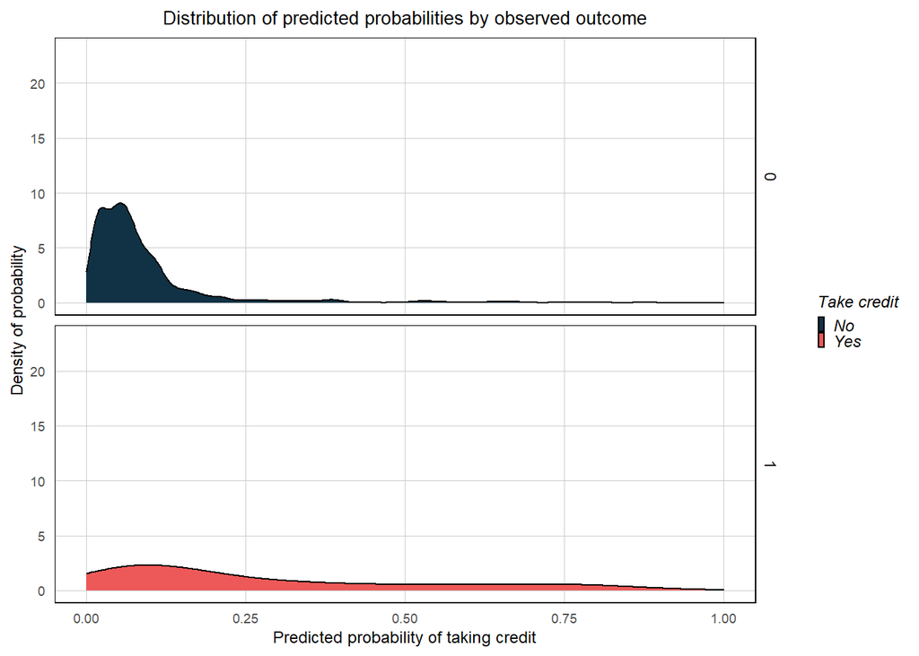

# The Final Model: An Improved one

## Feature Engineering

To improve our model, we recategorized some of the variables based on their distribution on the previous model

```r
# Age Groups
housing <-
  housing %>%
  mutate(age_cat = case_when(
    age <= 50 ~ "Below 50",
    age > 50  ~ "Above 50"))

# Pdays
housing <-
  housing %>%
  mutate(pdays_cat = case_when(pdays == 999 ~ "Not Contacted",
                             TRUE  ~ "Contacted"))
#Previous
housing <-
  housing %>%
  mutate(previous_cat = case_when(previous == 0 ~ "0",
                               previous == 1 ~ "1" ,
                               previous > 1 ~ "Other"))
#campaign
housing <-
  housing %>%
  mutate(campaign_cat = case_when(
    campaign == 1   ~ "1",
    campaign == 2  ~ "2",
    campaign >= 3  ~ "At least 3"))

# Education
housing <-
  housing %>%
  mutate(education_cat = case_when(
    education == "basic.9y" |education == "basic.6y" | education == "basic.4y" ~ "Less Than HS",
    education == "high.school"  ~ "High School",
    education == "university.degree" |education == "professional.course"  ~ "Higher Education",
    education == "unknown" |education == "illiterate"  ~ "Other"))

#Month
housing <-
  housing %>%
  mutate(month_cat = case_when(
    month == "dec" |month == "mar" | month == "oct" | month == "sep" ~ "Off-peak",
    TRUE ~ "Peak"))

# Employment Status
housing <-
  housing %>%
  mutate(job_cat = case_when(job == "student" | job == "unemployed" | job == "retired" ~ "unemployed", TRUE  ~ "employed"))

#Spent on repairs
housing <-
  housing %>%
  mutate(spent_on_repairs_cat = case_when(
    spent_on_repairs <5090    ~ "Under $5090",
    spent_on_repairs > 5170  ~ "Over $5170",
    TRUE ~ "Other"))

#Inflation
housing <-
  housing %>%
  mutate(inflation_rate_cat = case_when(
    inflation_rate <= 3   ~ "Over 3",
    inflation_rate > 3  ~ "Under 3"))
```

```
##
## Regression Results - Final Model
## =========================================================
##                                   Dependent variable:
##                               ---------------------------
##                                        y_numeric
## ---------------------------------------------------------
## X                                       -0.0001
##                                        (0.0001)
##
## age                                      0.015
##                                         (0.012)
##
## jobblue-collar                          -0.364
##                                         (0.284)
##
## jobentrepreneur                         -0.323
##                                         (0.444)
##
## jobhousemaid                            -0.721
##                                         (0.548)
##
## jobmanagement                           -0.609*
##                                         (0.328)
##
## jobretired                              -0.179
##                                         (0.375)
##
## jobself-employed                        -0.573
##                                         (0.427)
##
## jobservices                             -0.162
##                                         (0.296)
##
## jobstudent                              -0.187
##                                         (0.436)
##
## jobtechnician                            0.044
##                                         (0.233)
##
```

[output cut: 144 more lines]

```
## 5090                                   1.766***
##                                         (0.407)
##
## inflation_rate_catUnder 3
##
##
## Constant                                -0.839
##                                         (1.560)
##
## ---------------------------------------------------------
## Observations                             2,678
## Log Likelihood                         -721.410
## Akaike Inf. Crit.                      1,552.820
## =========================================================
## Note:                         *p<0.1; **p<0.05; ***p<0.01
```

According to general rules of thumb for McFadden R2 interpretations, a value of 0.20+ indicates that the model is well fit. Here we can see that our model scored at 0.23, meaning that it is a reliable fit for us to derive conclusions from. Now, this alone does not describe the range of probabilities for churn or no churn. For that, the next section runs a test on the probabilities’ distribution.

# Distribution of predicted probabilities

The plot below shows the distribution of predicted probabilities for churn(1) and no churn(0). The model is predicting that more people may NOT take the credit than the people that would.

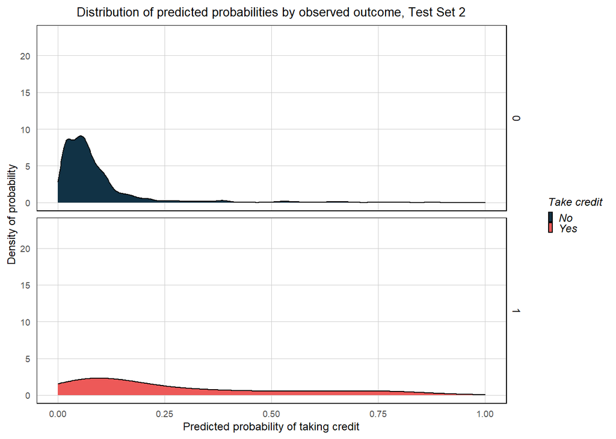

```r
testProbs2 = data.frame(observed = as.factor(housingTest2$y_numeric),
                       probs = predict(kitchensink, housingTest2, type = 'response'))

ggplot(testProbs2, aes(x = probs, fill = as.factor(observed))) +
  geom_density() +
  facet_grid(observed ~ ., labeller = ) +
  scale_fill_manual(values = palette2, name = 'Take credit',
                    labels = c('No', 'Yes')) +
  labs(x = 'Predicted probability of taking credit',
       y = 'Density of probability',
       title = 'Distribution of predicted probabilities by observed outcome, Test Set 2') +
  xlim(0, 1) +
  ylim(0, 23) +
  plotTheme2()
```

# Model Evaluation

## ROC curve

The ROC curve allows us to split the predicted outcomes in various thresholds to better understand the performance of the model in predicting either churn or no churn better. In here, we use a confusion matrix that helps identify the question.

Confusion Matrix Summary:

```r
testProbs2 <-
  testProbs2 %>%
  mutate(predOutcome  = as.factor(ifelse(testProbs2$probs > 0.5 , 1, 0)))

caret::confusionMatrix(testProbs2$predOutcome, testProbs2$observed,
                       positive = "1")
```

```
## Confusion Matrix and Statistics
##
##           Reference
## Prediction    0    1
##          0 1268  109
##          1   31   33
##
##                Accuracy : 0.9028
##                  95% CI : (0.8864, 0.9177)
##     No Information Rate : 0.9015
##     P-Value [Acc > NIR] : 0.4519
##
##                   Kappa : 0.2761
##
##  Mcnemar's Test P-Value : 0.00000000007632
##
##             Sensitivity : 0.23239
##             Specificity : 0.97614
##          Pos Pred Value : 0.51563
##          Neg Pred Value : 0.92084
##              Prevalence : 0.09854
##          Detection Rate : 0.02290
##    Detection Prevalence : 0.04441
##       Balanced Accuracy : 0.60426
##
##        'Positive' Class : 1
##
```

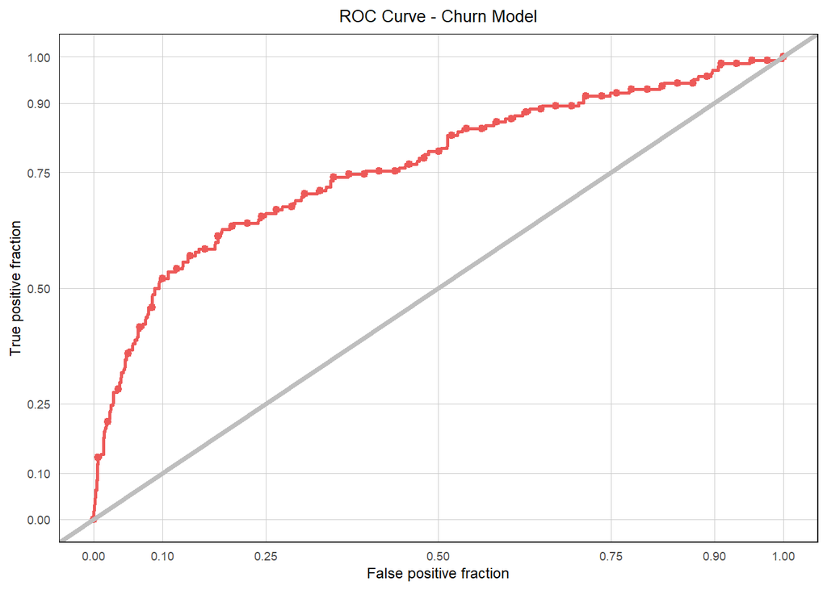

```r
ggplot(testProbs2, aes(d = as.numeric(testProbs2$observed), m = probs)) +
  geom_roc(n.cuts = 50, labels = FALSE, colour = "#ed5958") +
  style_roc(theme = theme_grey) +
  geom_abline(slope = 1, intercept = 0, size = 1.5, color = 'grey') +
  labs(title = "ROC Curve - Churn Model") +
  plotTheme2()
```

```r
pROC::auc(testProbs2$observed, testProbs2$probs)
```

```
## Area under the curve: 0.7635
```

Kitchen Sink vs Final Model ROC Plots

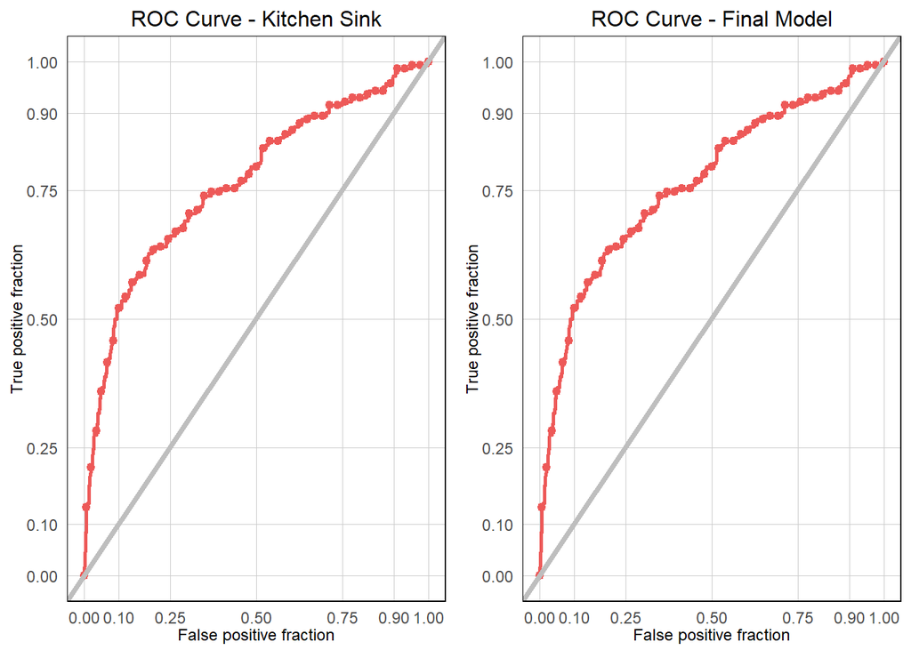

```r
a1 <- ggplot(testProbs, aes(d = as.numeric(testProbs$observed), m = probs)) +
  geom_roc(n.cuts = 50, labels = FALSE, colour = "#ed5958") +
  style_roc(theme = theme_grey) +
  geom_abline(slope = 1, intercept = 0, size = 1.5, color = 'grey') +
  labs(title = "ROC Curve - Kitchen Sink") +
  plotTheme()

a2 <- ggplot(testProbs2, aes(d = as.numeric(testProbs2$observed), m = probs)) +
  geom_roc(n.cuts = 50, labels = FALSE, colour = "#ed5958") +
  style_roc(theme = theme_grey) +
  geom_abline(slope = 1, intercept = 0, size = 1.5, color = 'grey') +
  labs(title = "ROC Curve - Final Model") +
  plotTheme()

ggarrange(a1, a2)
```

## Cross Validation

The Cross validation part helps to measure generalizability to new data. It splits the data into to sets and runs 100 k-folds over the data, outcoming predicted probabilities (classProbs).

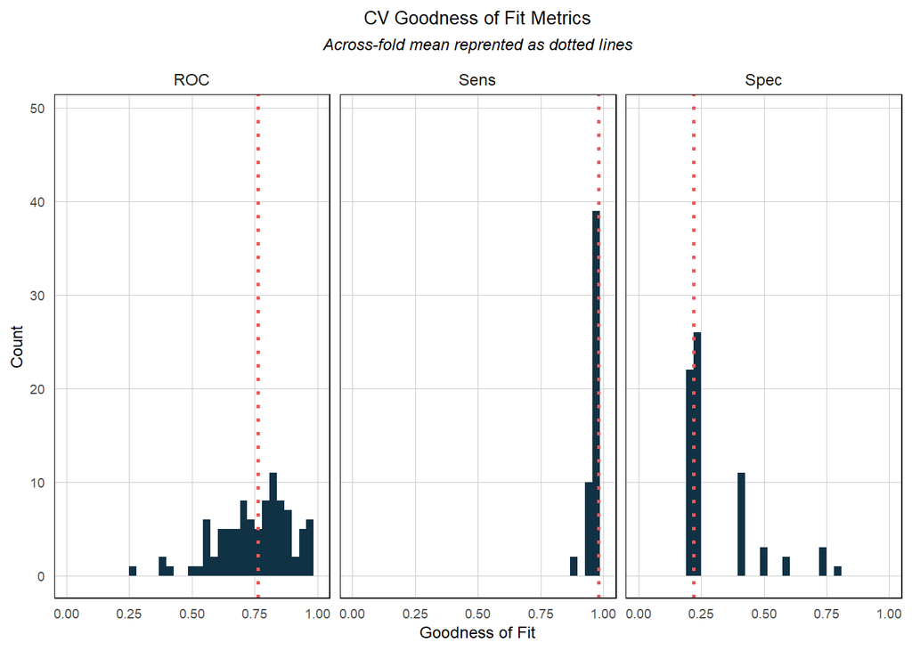

```r
ctrl <- trainControl(method = "cv", number = 100, classProbs=TRUE, summaryFunction=twoClassSummary)

cvFit <- train(y ~ .,
                  data = housing %>%
                    na.omit() %>%
                    dplyr::select(-cons.price.idx, -cons.conf.idx, -y_numeric, -spent_on_repairs,
                                  -previous),
                method="glm", family="binomial",
                metric="ROC", trControl = ctrl)


dplyr::select(cvFit$resample, -Resample) %>%
   gather(metric, value) %>%
   left_join(gather(cvFit$results[2:4], metric, mean)) %>%
   ggplot(aes(value)) +
   geom_histogram(bins=35, fill = "#113245") +
   facet_wrap(~metric) +
   geom_vline(aes(xintercept = mean), colour = "#ed5958", linetype = 3, size = 1) +
   scale_x_continuous(limits = c(0, 1)) +
   labs(x="Goodness of Fit", y="Count", title="CV Goodness of Fit Metrics",
        subtitle = "Across-fold mean reprented as dotted lines")+
   plotTheme2()
```

## Confusion Matrix for Kitchen Sink (Baseline)

Predictions:

```r
testProbs <-
  testProbs %>%
  mutate(predOutcome  = as.factor(ifelse(testProbs$probs > 0.5 , 1, 0)))

caret::confusionMatrix(testProbs$predOutcome, testProbs$observed,
                       positive = "1")
```

```
## Confusion Matrix and Statistics
##
##           Reference
## Prediction    0    1
##          0 1268  109
##          1   31   33
##
##                Accuracy : 0.9028
##                  95% CI : (0.8864, 0.9177)
##     No Information Rate : 0.9015
##     P-Value [Acc > NIR] : 0.4519
##
##                   Kappa : 0.2761
##
##  Mcnemar's Test P-Value : 0.00000000007632
##
##             Sensitivity : 0.23239
##             Specificity : 0.97614
##          Pos Pred Value : 0.51563
##          Neg Pred Value : 0.92084
##              Prevalence : 0.09854
##          Detection Rate : 0.02290
##    Detection Prevalence : 0.04441
##       Balanced Accuracy : 0.60426
##
##        'Positive' Class : 1
##
```

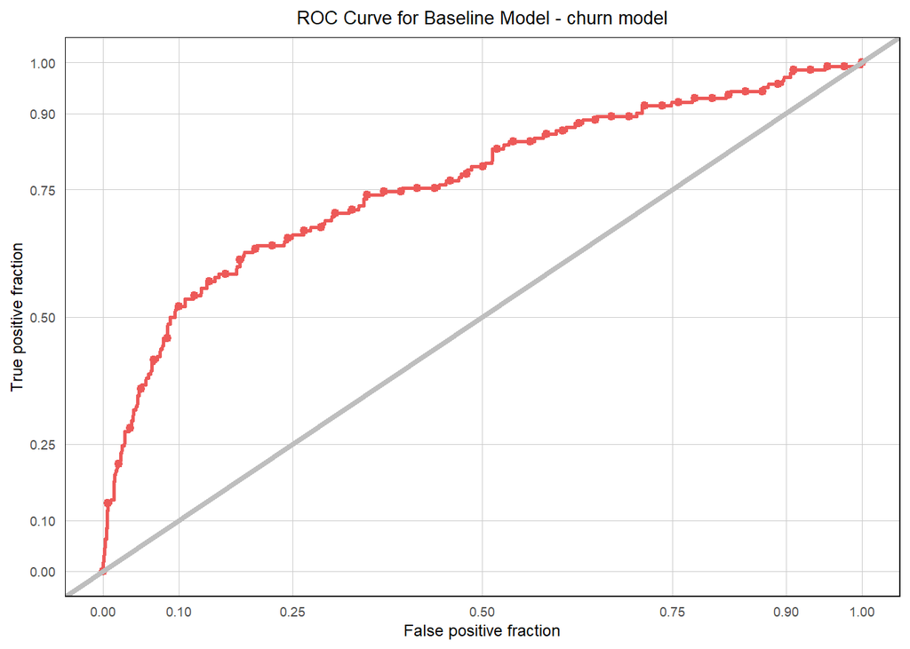

```r
ggplot(testProbs, aes(d = as.numeric(testProbs$observed), m = probs)) +
  geom_roc(n.cuts = 50, labels = FALSE, colour = "#ed5958") +
  style_roc(theme = theme_grey) +
  geom_abline(slope = 1, intercept = 0, size = 1.5, color = 'grey') +
  labs(title = "ROC Curve for Baseline Model - churn model") +
  plotTheme2()
```

Small multiple plot, Goodness of Fit for the baseline model

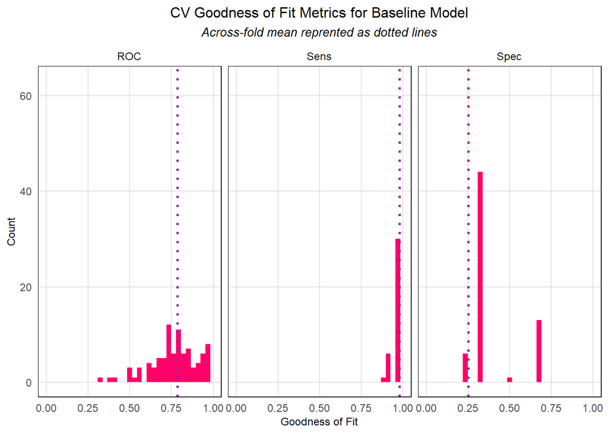

```r
ctrl <- trainControl(method = "cv", number = 100, classProbs=TRUE, summaryFunction=twoClassSummary)


cvFit_Ks <- train(y ~ .,
                  data = housingTrain %>%
                    na.omit() %>%
                    dplyr::select(-cons.price.idx, -cons.conf.idx, -y_numeric, -spent_on_repairs,
                                  -previous, -education),
                method="glm", family="binomial",
                metric="ROC", trControl = ctrl)


dplyr::select(cvFit_Ks$resample, -Resample) %>%
  gather(metric, value) %>%
  left_join(gather(cvFit_Ks$results[2:4], metric, mean)) %>%
  ggplot(aes(value)) +
    geom_histogram(bins=35, fill = "#FF006A") +
    facet_wrap(~metric) +
    geom_vline(aes(xintercept = mean), colour = "#981FAC", linetype = 3, size = 1) +
    scale_x_continuous(limits = c(0, 1)) +
    labs(x="Goodness of Fit", y="Count", title="CV Goodness of Fit Metrics for Baseline Model",
         subtitle = "Across-fold mean reprented as dotted lines") +
    plotTheme()
```

# Cross Validation:

## Cost Benefit Analysis

We developed a cost-benefit analysis that would help the Department of Housing and Community Development allocate its resources more efficiently. The following assumptions were made about the marketing campaign:

• $2,850 HCD allocation per homeowner

• 25% of contacted eligible homeowners take the credit

• $5000 credit cost per homeowner

• Houses that transacted after taking the credit sold with $10,000 premium

Thresholds for cross benefit calculations are described below:

**True Negative Revenue** - Predicted correctly homeowner would not take the credit, no marketing resources were allocated, and no credit was allocated. Count*0

Table 3: Cost/Benefit Table

[output not shown]

[output not shown]

# Optimizing Cost/Benefit Relationship

Ideally, the ‘optimal’ threshold is the one that returns the greatest cost/benefit. In this section, a function is created to iteratively loop through each threshold, calculate confusion metrics, and total the revenue for each. The results are then visualized for each scenario. At a lower threshold, we see the costs associated with the false positives, which eventually flattens the ~0.65 mark.

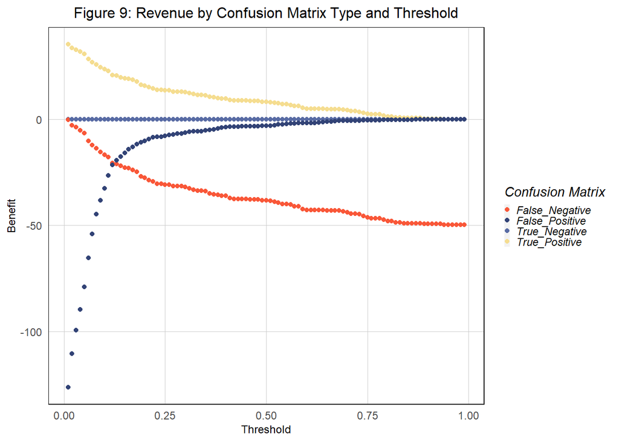

```r
iterateThresholds.1 <- function(data) {
  x = .01
  all_prediction <- data.frame()
  while (x <= 1) {
  this_prediction <-
      testProbs %>%
      mutate(predOutcome = ifelse(probs > x, 1, 0)) %>%
      count(predOutcome, observed) %>%
      summarize(True_Negative = sum(n[predOutcome==0 & observed==0]),
                True_Positive = sum(n[predOutcome==1 & observed==1]),
                False_Negative = sum(n[predOutcome==0 & observed==1]),
                False_Positive = sum(n[predOutcome==1 & observed==0])) %>%
     gather(Variable, Count) %>%
     mutate(Revenue =
               ifelse(Variable == "True_Negative", Count * 0,
               ifelse(Variable == "True_Positive",((.35 - .1) * Count),
               ifelse(Variable == "False_Negative", (-0.35) * Count,
               ifelse(Variable == "False_Positive", (-0.1) * Count, 0)))),
            Threshold = x)
  all_prediction <- rbind(all_prediction, this_prediction)
  x <- x + .01
  }
return(all_prediction)
}


whichThreshold <- iterateThresholds.1(testProbs2)

whichThreshold_revenue <-
whichThreshold %>%
    group_by(Threshold) %>%
    summarize(Revenue = sum(Revenue))

whichThreshold %>%
  ggplot(.,aes(Threshold, Revenue, colour = Variable)) +
  geom_point() +
  scale_colour_manual(values = palette5[c(5, 1:3)]) +
  labs(title = "Figure 9: Revenue by Confusion Matrix Type and Threshold",
       y = "Benefit") +
  plotTheme() +
  guides(color=guide_legend(title = "Confusion Matrix"))
```

## Plot of Threshold as a Function of Revenue and Count of Credits

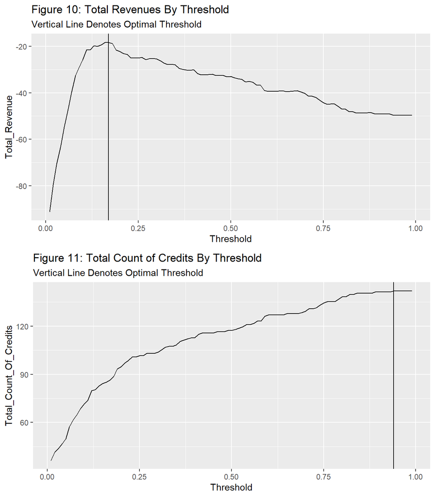

```r
whichThreshold_revenue <-
  whichThreshold %>%
  mutate(TookCredit = ifelse(Variable == "True_Positive", (Count * .25),
                         ifelse(Variable == "False_Negative", Count, 0))) %>%
  group_by(Threshold) %>%
  summarize(Total_Revenue = sum(Revenue), Total_Count_Of_Credits = sum(TookCredit))

#Plot
grid.arrange(ncol = 1,
             ggplot(whichThreshold_revenue) +
               geom_line(aes(x = Threshold, y = Total_Revenue)) +
               geom_vline(xintercept =  pull(arrange(whichThreshold_revenue, -Total_Revenue)[1,1])) +
               labs(title = "Figure 10: Total Revenues By Threshold",
                    subtitle = "Vertical Line Denotes Optimal Threshold"),
             ggplot(whichThreshold_revenue) +
               geom_line(aes(x = Threshold, y = Total_Count_Of_Credits))+
               geom_vline(xintercept =  pull(arrange(whichThreshold_revenue, -Total_Count_Of_Credits)[1,1])) +
               labs(title = "Figure 11: Total Count of Credits By Threshold",
                    subtitle = "Vertical Line Denotes Optimal Threshold"))
```

```r
whichThreshold_revenue %>%
  kable()%>%
  kable_styling()
```

| Threshold | Total_Revenue | Total_Count_Of_Credits |
| --- | --- | --- |
| 0.01 | -91.3 | 36.25 |
| 0.02 | -79.6 | 41.50 |
| 0.03 | -70.4 | 43.75 |
| 0.04 | -63.1 | 46.75 |
| 0.05 | -54.8 | 49.75 |
| 0.06 | -47.1 | 57.25 |
| 0.07 | -39.6 | 61.75 |
| 0.08 | -32.6 | 64.75 |
| 0.09 | -29.1 | 68.50 |
| 0.10 | -25.9 | 71.50 |
| 0.11 | -21.5 | 73.75 |
| 0.12 | -21.5 | 79.75 |
| 0.13 | -19.8 | 80.50 |
| 0.14 | -20.0 | 82.75 |
| 0.15 | -19.4 | 84.25 |
| 0.16 | -18.3 | 85.00 |
| 0.17 | -18.3 | 86.50 |
| 0.18 | -18.8 | 88.75 |
| 0.19 | -21.5 | 93.25 |
| 0.20 | -22.2 | 94.75 |
| 0.21 | -23.1 | 97.00 |
| 0.22 | -23.5 | 98.50 |
| 0.23 | -25.0 | 100.75 |
| 0.24 | -24.9 | 100.75 |
| 0.25 | -25.1 | 101.50 |
| 0.26 | -24.8 | 101.50 |
| 0.27 | -25.8 | 103.00 |
| 0.28 | -25.3 | 103.00 |
| 0.29 | -25.2 | 103.00 |
| 0.30 | -25.5 | 103.75 |

[output cut: 69 more lines]

```r
optimalthreshold <-
  whichThreshold_revenue %>%
  dplyr::select(Threshold, Total_Revenue, Total_Count_Of_Credits)

optimalthreshold_table <-
  whichThreshold_revenue %>%
  dplyr::select(Threshold, Total_Revenue, Total_Count_Of_Credits)

optimalthreshold_table <-
  optimalthreshold %>%
  filter(row(optimalthreshold) == c(25, 50))

kable(optimalthreshold_table,
       caption = "Cost Benefit Table") %>% kable_styling()
```

Cost Benefit Table

| Threshold | Total_Revenue | Total_Count_Of_Credits |
| --- | --- | --- |
| 0.25 | -25.1 | 101.50 |
| 0.50 | -33.0 | 117.25 |

# Conclusion

Our model does fairly well at identifying homeowners who were not going to take the credit, which could help HCD save resources by not allocating funds for marketing and information sessions to a group of people who would never accept the credit anyway. However, the model is not the best for identifying those who would take the credit (True Positives). Perhaps adding other features, such as characteristics of homes, location of homes, could improve our model. Additionally, HCD could benefit as well from doing survey work throughout the community as a support for characteristics to help define groups that are likely to accept the credit.